# 2.6 OLS: Precision and Diagnostics - R Practice (Solutions)

Ryan Safner

2019-10-04

# Set Up

To minimize confusion, I suggest creating a new `R Project` (e.g. `regression_practice`) and storing any data in that folder on your computer.

Alternatively, I have made a project in R Studio Cloud that you can use (and not worry about trading room computer limitations), with the data already inside (you will still need to assign it to an object).

- [View Project on R Studio Cloud](https://rstudio.cloud/project/575252)

## Question 1

Our [data](https://github.com/fivethirtyeight/data/tree/master/congress-trump-score) comes from fivethirtyeight’s [Trump Congress tracker](https://projects.fivethirtyeight.com/congress-trump-score/). Download and read in (`read_csv`) the data.

- `congress-trump-score.csv`

```r
library(tidyverse)
# again, my path (on website) may be different than yours
congress<-read_csv("../data/congress-trump-score.csv")
```

## Question 2

Look at the data with `glimpse()`.

```r
congress %>%
  glimpse()
```

```
## Observations: 1,735
## Variables: 11
## $ congress        <dbl> 0, 115, 116, 0, 115, 116, 0, 115, 116, 0, 115, 1…
## $ chamber         <chr> "house", "house", "house", "house", "house", "ho…
## $ bioguide        <chr> "A000055", "A000055", "A000055", "A000367", "A00…
## $ last_name       <chr> "Aderholt", "Aderholt", "Aderholt", "Amash", "Am…
## $ state           <chr> "AL", "AL", "AL", "MI", "MI", "MI", "NV", "NV", …
## $ district        <dbl> 4, 4, 4, 3, 3, 3, 2, 2, 2, 12, 12, 12, 31, 31, 3…
## $ party           <chr> "Republican", "R", "R", "Independent", "R", "I",…
## $ votes           <dbl> 141, 95, 46, 140, 96, 44, 140, 94, 46, 138, 92, …
## $ agree_pct       <dbl> 0.97872340, 0.96842105, 1.00000000, 0.62142857, …
## $ predicted_agree <dbl> 0.95556332, 0.94634916, 0.97459258, 0.77280357, …
## $ net_trump_vote  <dbl> 63.0, 63.0, 63.0, 9.4, 9.4, 9.4, 12.3, 12.3, 12.…
```

## Question 3

We want to see *how does the percentage that a member of Congress’ agrees with President Trump (`agree_pct`) depend on the result of the 2016 Presidential election in their district (`net_trump_vote`)*? First, plot a scatterplot of `agree_pct` on `net_trump_vote`. Add a regression line with an additional layer of `geom_smooth(method="lm")`.

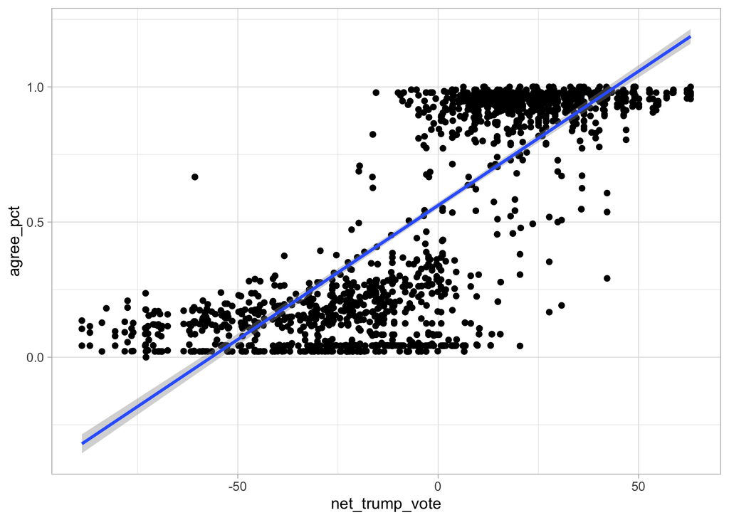

```r
scatter<-ggplot(data = congress)+
  aes(x = net_trump_vote, y=agree_pct)+
  geom_point()+
  geom_smooth(method="lm")+
  theme_light()
scatter
```

## Question 4

Find the correlation between `agree_pct` and `net_trump_vote`.

```r
# using base R
cor(congress$net_trump_vote, congress$agree_pct)
```

```
## [1] 0.7784996
```

```r
# using tidyverse
congress %>%
  summarize(cor = cor(net_trump_vote, agree_pct))
```

| cor |
| --- |
| 0.7784996 |

## Question 5

We weant to predict the following model:

$$\widehat{\text{agree_pct}}= \hat{\beta_0}+\hat{\beta_1}\text{net_trump_vote}$$

Run a regression, and save it as an object. Now get a `summary()` of it.

```r
reg<-lm(agree_pct ~ net_trump_vote, data = congress)
summary(reg)
```

```
##
## Call:
## lm(formula = agree_pct ~ net_trump_vote, data = congress)
##
## Residuals:
##      Min       1Q   Median       3Q      Max
## -0.72261 -0.16975  0.03761  0.19851  0.70728
##
## Coefficients:
##                 Estimate Std. Error t value Pr(>|t|)
## (Intercept)    0.5616451  0.0060307   93.13   <2e-16 ***
## net_trump_vote 0.0099218  0.0001922   51.63   <2e-16 ***
## ---
## Signif. codes:  0 '***' 0.001 '**' 0.01 '*' 0.05 '.' 0.1 ' ' 1
##
## Residual standard error: 0.251 on 1733 degrees of freedom
## Multiple R-squared:  0.6061, Adjusted R-squared:  0.6058
## F-statistic:  2666 on 1 and 1733 DF,  p-value: < 2.2e-16
```

### Part A

What is $\hat{\beta_0}$? What does it mean in the context of our question?

```r
# I just want to show you how to extract these and put it into text with markdown
# This relies on the code in Question 6 Part B
library(broom)
reg_tidy<-reg %>%
  tidy()

beta_0_hat<-reg_tidy %>% # save this as beta_0_hat
  slice(1) %>% # look only at first row (intercept)
  pull(estimate) %>% # extract the value of the estimate
  round(.,2) # round to 2 decimal places

beta_0_hat # look at it
```

```
## [1] 0.56
```

$\hat{\beta_0}=$ 0.56, meaning the rate at which Members of Congress agree with the President when the Net Trump Vote was 0 (i.e. both candidates got 50%) is 0.56 (out of 1).[^1]

### Part B

What is $\hat{\beta_1}$? What does it mean in the context of our question?

```r
beta_1_hat<-reg_tidy %>% # save this as beta_0_hat
  slice(2) %>% # look only at second row (net_trump_score)
  pull(estimate) %>% # extract the value of the estimate
  round(.,2) # round to 2 decimal places

beta_1_hat # look at it
```

```
## [1] 0.01
```

$\hat{\beta_1}=$ 0.01, meaning for every additional Net Trump Vote % in a Member of Congress’ district, that Member will agree 0.01 more with the President (out of 1).

### Part C

What is $R^2$? What does it mean?

```r
# this uses the glance command in question 6 part C.

r_sq<-glance(reg)$r.squared %>%
  round(.,2) # round to 2 decimals

r_sq # look at it
```

```
## [1] 0.61
```

$R^2 =$ 0.61, meaning we have explained 61%[^2] of the variation in `agree_pct`.

### Part D

What is the $SER$? What does it mean?

```r
# this uses the glance command in question 6 part C.

ser<-glance(reg)$sigma %>%
  round(.,2) # round to 2 decimals

ser # look at it
```

```
## [1] 0.25
```

$SER =$ 0.25, meaning the average size of the residuals or errors (distance from an actual data point to the predicted regression line) is 0.25 (out of 1).

## Question 6

We can look at regression outputs in a tidier way, with the `broom` package.

### Part A

Install and then load `broom`.

```r
#install.packages("broom")
library(broom)
```

### Part B

Run the function `tidy()` on your regression object (saved in question 5). Save this as an object and then look at it.

```r
reg_tidy<-reg %>%
  tidy()
reg_tidy
```

| term | estimate | std.error | statistic | p.value |
| --- | --- | --- | --- | --- |
| (Intercept) | 0.561645133 | 0.0060306814 | 93.13129 | 0 |
| net_trump_vote | 0.009921844 | 0.0001921538 | 51.63492 | 0 |

### Part C

Run the `glance()` function on your original regression object. What does it show you?

```r
reg %>%
  glance()
```

| r.squared | adj.r.squared | sigma | statistic | p.value | df | logLik | AIC | BIC | deviance | df.residual |
| --- | --- | --- | --- | --- | --- | --- | --- | --- | --- | --- |
| 0.6060616 | 0.6058343 | 0.2510093 | 2666.165 | 0 | 2 | -62.62784 | 131.2557 | 147.632 | 109.1889 | 1733 |

It shows you summary statistics of the regression, particularly its goodness of fit.

- `r.squared` is the $R^2$ value
- `sigma` is the $SER \; (\hat{\sigma_u})$

That’s all we need for now.

### Part D

Now run the `augment()` function on your original regression object, and save this as an object. Look at it. What does it show you?

```r
reg_aug<-reg %>%
  augment()
reg_aug
```

| agree_pct | net_trump_vote | .fitted | .se.fit | .resid | .hat | .sigma | .cooksd | .std.resid |
| --- | --- | --- | --- | --- | --- | --- | --- | --- |
| 0.97872340 | 63.0000000 | 1.186721301 | 0.013732227 | -0.2079978972 | 0.0029929687 | 0.2510319 | 1.033746e-03 | -0.829888862 |
| 0.96842105 | 63.0000000 | 1.186721301 | 0.013732227 | -0.2183002488 | 0.0029929687 | 0.2510268 | 1.138687e-03 | -0.870994118 |
| 1.00000000 | 63.0000000 | 1.186721301 | 0.013732227 | -0.1867213015 | 0.0029929687 | 0.2510416 | 8.330742e-04 | -0.744997572 |
| 0.62142857 | 9.4000000 | 0.654910466 | 0.006362055 | -0.0334818950 | 0.0006424141 | 0.2510805 | 5.722469e-06 | -0.133431902 |
| 0.54166667 | 9.4000000 | 0.654910466 | 0.006362055 | -0.1132437998 | 0.0006424141 | 0.2510670 | 6.546245e-05 | -0.451298696 |
| 0.79545455 | 9.4000000 | 0.654910466 | 0.006362055 | 0.1405440790 | 0.0006424141 | 0.2510591 | 1.008297e-04 | 0.560095649 |
| 0.97857143 | 12.3000000 | 0.683683814 | 0.006561991 | 0.2948876147 | 0.0006834260 | 0.2509817 | 4.722680e-04 | 1.175208948 |
| 0.98936170 | 12.3000000 | 0.683683814 | 0.006561991 | 0.3056778883 | 0.0006834260 | 0.2509743 | 5.074620e-04 | 1.218211181 |
| 0.95652174 | 12.3000000 | 0.683683814 | 0.006561991 | 0.2728379253 | 0.0006834260 | 0.2509961 | 4.042825e-04 | 1.087334819 |
| 0.12318841 | -40.0000000 | 0.164771376 | 0.009584055 | -0.0415829702 | 0.0014578700 | 0.2510798 | 2.006352e-05 | -0.165783923 |

[output cut: 1725 more lines]

It takes the original data points for `Y` and `X` and adds new variables with values for those observations: - `.fitted` is $\hat{Y_i|X}$, the predicted value for a specific `net_trump_vote` - `.resid` is $\hat{u_i}$, the residual or error for a specific `net_trump_vote`
$$\begin{align*}
\hat{u_i}&=Y_i-\hat{Y_i}\\
.resid &= agree\text{_}pct - .fitted\\
\end{align*}$$

That’s all we need right now.

## Question 7

Now let’s start looking at the residuals of the regression.

### Part A

Take the augmented regression object from Question 6-D and use it as the source of your data to create a histogram, where $x$ is `.resid`. Does it look roughly normal?

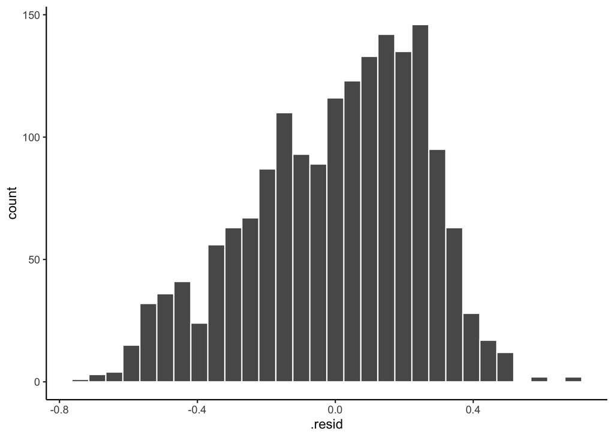

```r
ggplot(data = reg_aug)+
  aes(x = .resid)+
  geom_histogram(color="white")+
  theme_classic()
```

It does look rougly normal.

### Part B

Take the augmented regression object and make a residual plot, which is a scatterplot where `x` is the normal `x` variable, and `y` is the `.resid`. Feel free to add a horizontal line at 0 with `geom_hline(yintercept=0)`.

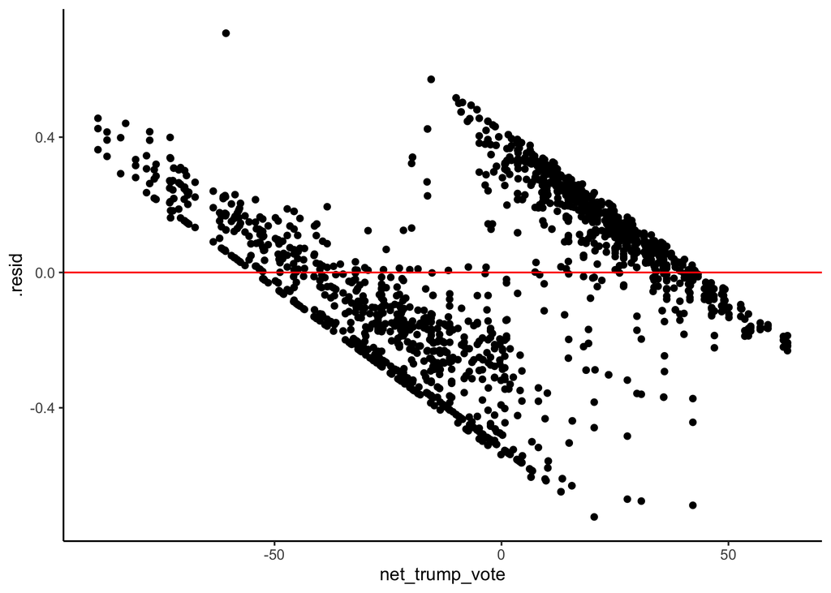

```r
ggplot(data = reg_aug)+
  aes(x = net_trump_vote, y=.resid)+
  geom_point()+
  geom_hline(yintercept = 0, color = "red")+
  theme_classic()
```

## Question 8

Now let’s try presenting your results in a regression table. Install and load `huxtable`, and run the `huxreg()` command. Your main input is your regression object you saved in Question 5. Feel free to customize the output of this table (see the slides).

```r
#install.packages("huxtable")
library(huxtable)
# basic
huxreg(reg)
```

|  | (1) |
| --- | --- |
| (Intercept) | 0.562 *** |
|  | (0.006) |
| net_trump_vote | 0.010 *** |
|  | (0.000) |
| N | 1735 |
| R2 | 0.606 |
| logLik | -62.628 |
| AIC | 131.256 |
| *** p < 0.001; ** p < 0.01; * p < 0.05. |  |

```r
# some customizations
huxreg("Agree with President (Proportion)" = reg,
       coefs = c("Intercept" = "(Intercept)",
                 "Net Trump Vote" = "net_trump_vote"),
       statistics = c("n" = "nobs",
                      "R-squared" = "r.squared",
                      "SER" = "sigma"),
       number_format = 4)
```

|  | Agree with President (Proportion) |
| --- | --- |
| Intercept | 0.5616 *** |
|  | (0.0060) |
| Net Trump Vote | 0.0099 *** |
|  | (0.0002) |
| n | 1735 |
| R-squared | 0.6061 |
| SER | 0.2510 |
| *** p < 0.001; ** p < 0.01; * p < 0.05. |  |

## Question 9

Now let’s check for heteroskedasticity.

### Part A

Looking at the scatterplot and residual plots in Questions 3 and 7B, do you think the errors are heteroskedastic or homoskedastic?

It does seem like it would be, looking at the residual plot, since there are clear downward-moving clusters of points that are at times above the line, then below the line, then above and below the line.

### Part B

Install and load the `lmtest` package and run `bptest` on your regression object. Was the data heteroskedastic or homoskedastic?

```r
#install.packages("lmtest")
library(lmtest)
bptest(reg)
```

```
##
##  studentized Breusch-Pagan test
##
## data:  reg
## BP = 6.0092, df = 1, p-value = 0.01423
```

Since the $p$-value was less than 0.05, we can reject the null hypothesis $H_0$ (that the errors are homoskedastic), and conclude that the errors are heteroskedastic. We will need to fix them if we want accurate standard errors.

### Part C

Now let’s make some heteroskedasticity-robust standard errors. Install and load the `estimatr` package and use the `lm_robust()` command (instead of the `lm()` command) to run a new regression (and save it). Make sure you add `se_type="stata"` inside the command to calculate robust SEs. Look at it. What changes?

```r
#install.packages("estimatr")
library(estimatr)

reg_rse<-lm_robust(agree_pct ~ net_trump_vote, data = congress, se_type="stata")
reg_rse
```

```
##                   Estimate   Std. Error  t value Pr(>|t|)    CI Lower
## (Intercept)    0.561645133 0.0060117565 93.42447        0 0.549854072
## net_trump_vote 0.009921844 0.0001493938 66.41403        0 0.009628833
##                  CI Upper   DF
## (Intercept)    0.57343619 1733
## net_trump_vote 0.01021486 1733
```

The standard errors on both estimates $(\hat{\beta_0}$ and $\hat{\beta_1})$ change, but the estimates themselves do not change!

Note `t values` and `Pr(>|t|)` will change, and this command adds confidence intervals (`CI`) and degrees of freedom for $t$, `DF`, but we have not covered any of these yet!

### Part D

Now let’s see this in a nice regression table. Use `huxreg()` again, but add both your original regression and your regression saved in part C. Notice any changes?

```r
huxreg("Original" = reg, "Robust SEs" = reg_rse,
       number_format = 6) # need to see more decimal places!
```

|  | Original | Robust SEs |
| --- | --- | --- |
| (Intercept) | 0.561645 *** | 0.561645 *** |
|  | (0.006031) | (0.006012) |
| net_trump_vote | 0.009922 *** | 0.009922 *** |
|  | (0.000192) | (0.000149) |
| N | 1735 | 1735 |
| R2 | 0.606062 | 0.606062 |
| logLik | -62.627843 |  |
| AIC | 131.255686 |  |
| *** p < 0.001; ** p < 0.01; * p < 0.05. |  |  |

## Question 10

Now let’s check for outliers.

### Part A

Just looking at the scatterplot in Question 3, do you see any outliers?

It looks like there might be one - for the Member whose district’s Net vote was somewhere around $-60$ and s/he agrees with the President about $0.6$.

### Part B

Install and load the `car` package. Run the `outlierTest` command on your regression object. Does it detect any outliers?

```r
#install.packages("car")
library(car)
outlierTest(reg)
```

```
## No Studentized residuals with Bonferroni p < 0.05
## Largest |rstudent|:
##       rstudent unadjusted p-value Bonferroni p
## 1708 -2.886125          0.0039485           NA
```

### Part C

Look in your original data to match this outlier with an observation. Hint: use the `slice()` command, as the outlier test gave you an observation (row) number!

```r
congress %>%
  slice(1708)
```

| congress | chamber | bioguide | last_name | state | district | party | votes | agree_pct | predicted_agree | net_trump_vote |
| --- | --- | --- | --- | --- | --- | --- | --- | --- | --- | --- |
| 116 | senate | T000464 | Tester | MT |  | D | 24 | 0.0417 | 0.751 | 20.4 |

## Question 11 (Optional)

This data is still a bit messy. Let’s check in on your `tidyverse` skills again! For example, we’d probably like to plot our scatterplots with colors for Republican and Democratic party. Or plot by the House and the Senate.

### Part A

First, the variable `congress` (session of Congress) seems a bit off. Get a `count()` of `congress`.

```r
congress %>%
  count(congress)
```

| congress | n |
| --- | --- |
| 0 | 647 |
| 115 | 552 |
| 116 | 536 |

### Part B

Let’s get rid of the `0` values for `congress` (someone made a mistake coding this, probably). Also, while we’re at it, let’s take `agree_pct` and `mutate` a variable that is a proper percentage (i.e. `*100`).

```r
congress_tidy<-congress %>%
  filter(congress!=0) %>%
  mutate(agree_pct = agree_pct * 100)
```

### Part C

The variable `party` is also quite a mess. `count()` by `party` to see. Then let’s `mutate` a variable to make a better measure of political party - just `"Republican"`, `"Democrat"`, and `"Independent"`. Try doing this with the `case_when()` command (as your `mutate` formula).[^3] When you’re done `count()` by your new party variable to make sure it worked.

```r
congress_tidy <- congress_tidy %>%
  mutate(pol_party = case_when(
    party %in% c("Democrat", "D") ~ "Democrat",
    party %in% c("Republican", "R") ~ "Republican",
    party %in% c("Independent", "I") ~ "Independent"
  ))

congress_tidy %>%
  count(pol_party)
```

| pol_party | n |
| --- | --- |
| Democrat | 528 |
| Independent | 5 |
| Republican | 555 |

### Part D

Now plot a scatterplot (same as Question 3) and set `color` to your party variable. Notice `R` uses its own default colors, which don’t match to the actual colors these political parties use! Make a vector where you define the party colors as follows: `party_colors <- c("Democrat" = "blue", "Republican" = "red", "Independent" = "gray")`. Then, run your plot again, adding the following line to customize the colors `+scale_colour_manual("Parties", values = party_colors)`.[^4]

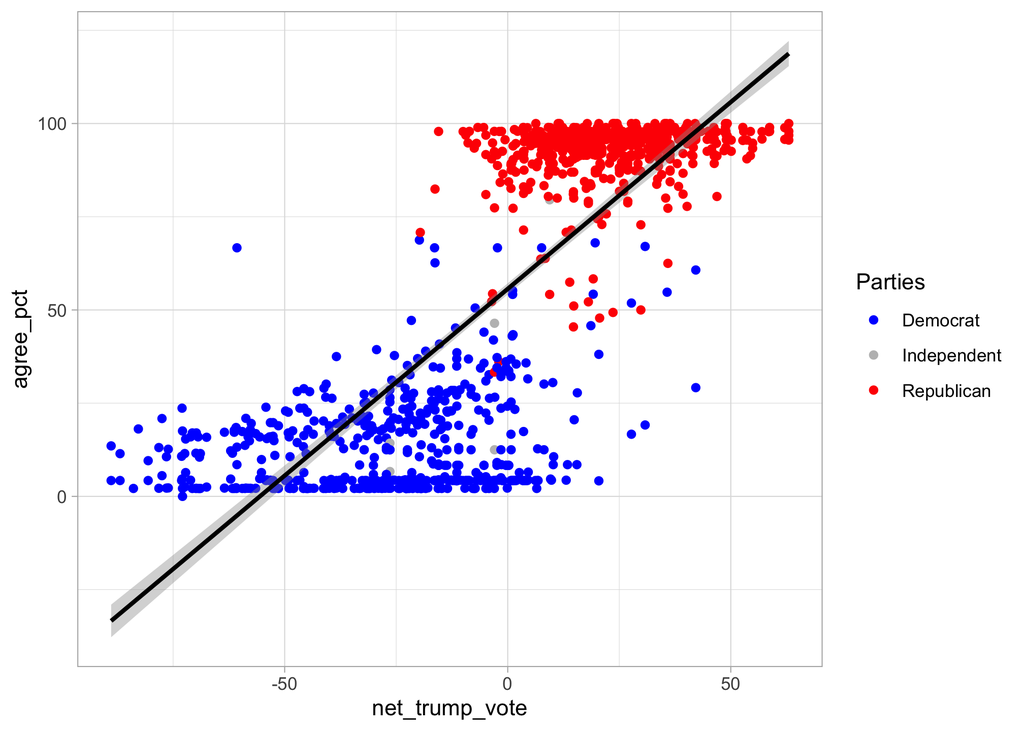

```r
party_colors <- c("Democrat" = "blue", "Republican" = "red", "Independent" = "gray")

p<-ggplot(data = congress_tidy)+
  aes(x = net_trump_vote, y=agree_pct)+
  geom_point(aes(color = pol_party))+
  geom_smooth(method="lm", color = "black")+
  scale_colour_manual("Parties", values = party_colors)+
  theme_light()
p
```

### Part E

Now facet your scatterplot by `chamber`.

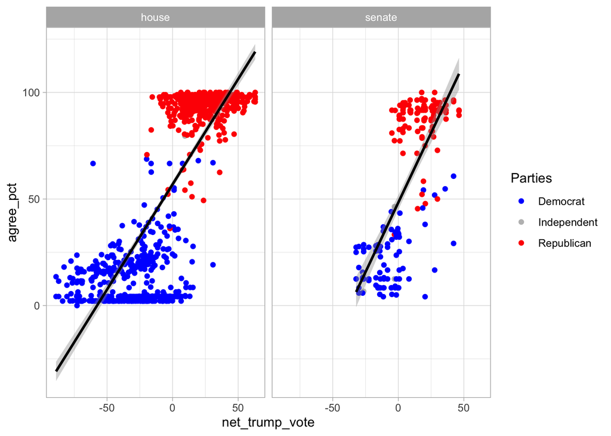

```r
p+facet_wrap(~chamber)
```

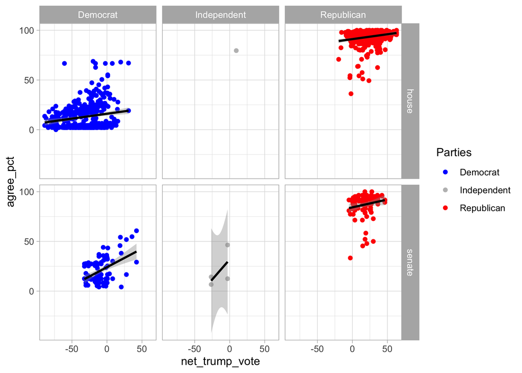

```r
# just for kicks
p+facet_grid(chamber~pol_party)
```

[^1]: Look at my markdown code to see that I can write my R code directly in my text with one backtick and r. This calls my `beta_0_hat` object I made.
[^2]: Again, look at my markdown: I am calling `r_sq` and multiplying it by 100 inside the code chunk.
[^3]: The syntax for `case_when()` is to have a series of `condition ~ "Outcome"`, separated by commas. For example, one condition is to assign both `"Democrat"` and `"D"` to `"Democrat"`, as in `party %in% c("Democrat", "D") ~ "Democrat"`. You could also do this with a few `ifelse()` commands, but that’s a bit more awkward.
[^4]: `"Parties"` is the title that will show up on the legend, feel free to edit it, or remove the legend with another layer `+guides(color = F)`.